# Wildlife Impacts

Catherine Williams

July 24, 2019

##### *[Tidy Tuesday](https://twitter.com/catrwilliams/status/1154214259829592064)*

# 1 Project Description

Tidy Tuesday has a weekly data project aimed at the R ecosystem. An emphasis is placed on understanding how to summarize and arrange data to make meaningful charts with ggplot2, tidyr, dplyr, and other tools in the tidyverse ecosystem.

# 2 Dataset

Data came from [FAA](https://wildlife.faa.gov/). The data consists of voluntarily reported airplane wildlife strikes since 1990. The data was pre-filtered to include only the major airlines in the USA: American Airlines, Delta, Southwest, and United. The information obtained may include date, time, location, animal species, type of damage, weather conditions, airplane information, and repair costs.

# 3 Setup

## 3.1 Load Libraries

```r
if (!require("ggradar")) devtools::install_github("ricardo-bion/ggradar", dependencies = TRUE)

if (!require("pacman")) install.packages("pacman")
pacman::p_load("data.table","tidyverse","visdat","lubridate","modeest","ggradar","scales")

theme_set(theme_classic())
```

## 3.2 Import Data

```r
df <- fread("https://raw.githubusercontent.com/rfordatascience/tidytuesday/master/data/2019/2019-07-23/wildlife_impacts.csv", stringsAsFactors=TRUE)

#remove duplicate rows
df <- df %>% distinct()
```

# 4 Data Wrangling & Analysis

- There are 56,449 observations and 21 variables.

## 4.1 View Data

```r
glimpse(df)
```

```
## Observations: 56,449
## Variables: 21
## $ incident_date         <fct> 2018-12-31T00:00:00Z, 2018-12-29T00:00:0...
## $ state                 <fct> FL, IN, N/A, N/A, N/A, FL, FL, N/A, N/A,...
## $ airport_id            <fct> KMIA, KIND, ZZZZ, ZZZZ, ZZZZ, KMIA, KMCO...
## $ airport               <fct> MIAMI INTL, INDIANAPOLIS INTL ARPT, UNKN...
## $ operator              <fct> AMERICAN AIRLINES, AMERICAN AIRLINES, AM...
## $ atype                 <fct> B-737-800, B-737-800, UNKNOWN, B-737-900...
## $ type_eng              <fct> D, D, NA, D, D, D, D, D, D, D, D, D, D, ...
## $ species_id            <fct> UNKBL, R, R2004, N5205, J2139, UNKB, UNK...
## $ species               <fct> Unknown bird - large, Owls, Short-eared ...
## $ damage                <fct> M?, N, NA, M?, M?, N, N, N, N, N, N, N, ...
## $ num_engs              <int> 2, 2, NA, 2, 2, 2, 2, 2, 2, 2, 2, 2, 2, ...
## $ incident_month        <int> 12, 12, 12, 12, 12, 12, 12, 12, 12, 12, ...
## $ incident_year         <int> 2018, 2018, 2018, 2018, 2018, 2018, 2018...
## $ time_of_day           <fct> Day, Night, NA, NA, NA, Day, Night, NA, ...
## $ time                  <int> 1207, 2355, NA, NA, NA, 955, 948, NA, NA...
## $ height                <int> 700, 0, NA, NA, NA, NA, 600, NA, NA, 0, ...
## $ speed                 <int> 200, NA, NA, NA, NA, NA, 145, NA, NA, 13...
## $ phase_of_flt          <fct> Climb, Landing Roll, NA, NA, NA, Approac...
## $ sky                   <fct> Some Cloud, NA, NA, NA, NA, NA, Some Clo...
## $ precip                <fct> None, NA, NA, NA, NA, NA, None, NA, NA, ...
## $ cost_repairs_infl_adj <int> NA, NA, NA, NA, NA, NA, NA, NA, NA, NA, ...
```

```r
head(df)
```

```
##           incident_date state airport_id                airport
## 1: 2018-12-31T00:00:00Z    FL       KMIA             MIAMI INTL
## 2: 2018-12-29T00:00:00Z    IN       KIND INDIANAPOLIS INTL ARPT
## 3: 2018-12-29T00:00:00Z   N/A       ZZZZ                UNKNOWN
## 4: 2018-12-27T00:00:00Z   N/A       ZZZZ                UNKNOWN
## 5: 2018-12-27T00:00:00Z   N/A       ZZZZ                UNKNOWN
## 6: 2018-12-27T00:00:00Z    FL       KMIA             MIAMI INTL
##             operator     atype type_eng species_id              species
## 1: AMERICAN AIRLINES B-737-800        D      UNKBL Unknown bird - large
## 2: AMERICAN AIRLINES B-737-800        D          R                 Owls
## 3: AMERICAN AIRLINES   UNKNOWN     <NA>      R2004      Short-eared owl
## 4: AMERICAN AIRLINES B-737-900        D      N5205     Southern lapwing
## 5: AMERICAN AIRLINES B-737-800        D      J2139         Lesser scaup
## 6: AMERICAN AIRLINES     A-319        D       UNKB         Unknown bird
##    damage num_engs incident_month incident_year time_of_day time height
## 1:     M?        2             12          2018         Day 1207    700
## 2:      N        2             12          2018       Night 2355      0
## 3:   <NA>       NA             12          2018        <NA>   NA     NA
## 4:     M?        2             12          2018        <NA>   NA     NA
## 5:     M?        2             12          2018        <NA>   NA     NA
## 6:      N        2             12          2018         Day  955     NA
##    speed phase_of_flt        sky precip cost_repairs_infl_adj
## 1:   200        Climb Some Cloud   None                    NA
## 2:    NA Landing Roll       <NA>   <NA>                    NA
## 3:    NA         <NA>       <NA>   <NA>                    NA
## 4:    NA         <NA>       <NA>   <NA>                    NA
## 5:    NA         <NA>       <NA>   <NA>                    NA
## 6:    NA     Approach       <NA>   <NA>                    NA
```

```r
df %>% mutate_if(is.character, as.factor) %>% summary()
```

```
##               incident_date       state         airport_id
##  2018-10-12T00:00:00Z:   56   N/A    :12168   ZZZZ   :10543
##  2018-10-21T00:00:00Z:   39   TX     : 7143   KDFW   : 2453
##  2018-09-29T00:00:00Z:   38   CA     : 5779   KDEN   : 2243
##  2018-10-11T00:00:00Z:   38   FL     : 3685   KORD   : 1963
##  2018-10-30T00:00:00Z:   38   IL     : 2739   KSMF   : 1651
##  2017-10-16T00:00:00Z:   36   CO     : 2435   KMCO   : 1066
##  (Other)             :56204   (Other):22500   (Other):36530
##                         airport                    operator
##  UNKNOWN                    :10543   AMERICAN AIRLINES :14874
##  DALLAS/FORT WORTH INTL ARPT: 2453   DELTA AIR LINES   : 9000
##  DENVER INTL AIRPORT        : 2243   SOUTHWEST AIRLINES:17915
##  CHICAGO O'HARE INTL ARPT   : 1963   UNITED AIRLINES   :14660
##  SACRAMENTO INTL            : 1651
##  ORLANDO INTL               : 1066
##  (Other)                    :36530
##        atype       type_eng       species_id
##  B-737-700: 9911   A   :    2   UNKBM  :14943
##  B-737-300: 7526   C   :   34   UNKBS  :14723
##  B-737-800: 5225   D   :56178   UNKB   : 3939
##  B-757-200: 4148   F   :    3   NE1    : 1504
##  A-320    : 3685   NA's:  232   O2205  : 1339
##  A-319    : 3018                YI005  : 1170
##  (Other)  :22936                (Other):18831
##                   species       damage         num_engs
##  Unknown bird - medium:14943   M   : 1888   Min.   :1.000
##  Unknown bird - small :14723   M?  : 1085   1st Qu.:2.000
##  Unknown bird         : 3939   N   :48133   Median :2.000
##  Gulls                : 1504   S   : 1026   Mean   :2.059
##  Mourning dove        : 1339   NA's: 4317   3rd Qu.:2.000
##  Barn swallow         : 1170                Max.   :4.000
##  (Other)              :18831                NA's   :231
##  incident_month  incident_year  time_of_day        time
##  Min.   : 1.00   Min.   :1990   Dawn : 1269   Min.   : -84
##  1st Qu.: 5.00   1st Qu.:2002   Day  :25113   1st Qu.: 930
##  Median : 8.00   Median :2010   Dusk : 1717   Median :1426
##  Mean   : 7.23   Mean   :2008   Night:12731   Mean   :1428
##  3rd Qu.: 9.00   3rd Qu.:2015   NA's :15619   3rd Qu.:1950
##  Max.   :12.00   Max.   :2018                 Max.   :2359
##                                               NA's   :25607
##      height            speed             phase_of_flt           sky
##  Min.   :    0.0   Min.   :  0.0   Approach    :20592   No Cloud  :18926
##  1st Qu.:    0.0   1st Qu.:130.0   Take-off run: 8226   Overcast  : 5445
##  Median :   50.0   Median :140.0   Climb       : 7656   Some Cloud:12102
##  Mean   :  984.2   Mean   :154.6   Landing Roll: 7240   NA's      :19976
##  3rd Qu.: 1000.0   3rd Qu.:170.0   Descent     :  661
##  Max.   :25000.0   Max.   :354.0   (Other)     : 1110
##  NA's   :17526     NA's   :29522   NA's        :10964
##        precip      cost_repairs_infl_adj
##  None     :32922   Min.   :      11
##  Rain     : 1686   1st Qu.:    5128
##  Fog      :  587   Median :   26783
##  Snow     :   85   Mean   :  242388
##  Fog, Rain:   58   3rd Qu.:   93124
##  (Other)  :    8   Max.   :16380000
##  NA's     :21103   NA's   :55834
```

```r
sapply(df, function(x) n_distinct(x)) %>% sort()
```

```
##              operator                   sky              type_eng
##                     4                     4                     5
##                damage              num_engs           time_of_day
##                     5                     5                     5
##                precip        incident_month          phase_of_flt
##                     8                    12                    25
##         incident_year                 state                 atype
##                    29                    59                    91
##                 speed                height            airport_id
##                   166                   340                   423
##               airport               species            species_id
##                   423                   527                   528
## cost_repairs_infl_adj                  time         incident_date
##                   529                  1331                  9880
```

## 4.2 Missing Values

View missing values in more detail.

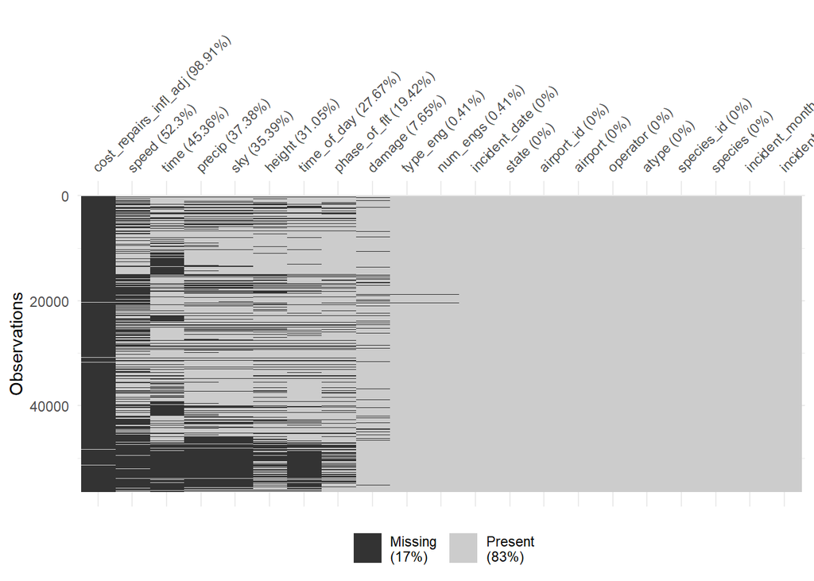

```r
#Visualize missing values
vis_miss(df, sort_miss=TRUE, warn_large_data = FALSE)
```

```r
#see count of missing values
na_values <- function(df){
  na <- colSums(is.na(df)) %>% sort(decreasing=TRUE)
  na[na>0]
}

na_values(df)
```

```
## cost_repairs_infl_adj                 speed                  time
##                 55834                 29522                 25607
##                precip                   sky                height
##                 21103                 19976                 17526
##           time_of_day          phase_of_flt                damage
##                 15619                 10964                  4317
##              type_eng              num_engs
##                   232                   231
```

## 4.3 Data Wrangling

- Dropped cost_repairs_infl_adj since the column is almost entirely missing.
- Dropped incident_month and incident_year since the information is contained in incident_date field.
- Cleaned up time by cross referencing to time_of_day and converting all times into military time.
- Merged date and time into a single column.

```r
#remove repair costs since there are too many missing values
df <- df %>% select(-cost_repairs_infl_adj,-incident_month,-incident_year)

#mutate date and time columns to join into a single column
df <- df %>% mutate(time = str_replace(time, "^\\d{1,2}$", paste0(time,"00")),
                    time = as.double(time),
                    time = case_when(time_of_day == "Night" & time < 1700 ~ time+1200,
                                     time_of_day == "Dusk" & time < 1200 ~ time+1200,
                                     is.na(time) ~ 0,
                                     TRUE ~ time),
                    time = str_pad(time, 4, side="left", pad="0"),
                    time = if_else(time_of_day == "Night" & time > 2400,
                                   str_pad(time, 6, side="left", pad="0"),
                                   str_pad(time, 6, side="right", pad="0")),
                    incident_date = str_sub(incident_date,1,10),
                    datetime = paste(incident_date,time),
                    #this will convert to date/time
                    datetime = as_datetime(datetime),
                    #need to put it back to character in order to make proper NA replacement
                    #it picks a random time instead of inserting 0s if this is not done
                    datetime = as.character(datetime),
                    #replace NA values generated from illegal time formats
                    datetime = replace(datetime,is.na(datetime),incident_date[is.na(datetime)]),
                    #convert back to date/time
                    datetime = as_datetime(datetime)) %>%
  select(-time,-incident_date)

#complete time_of_day based on time of year, day, and location
df <- df %>% mutate(month = month(datetime),
                    hour = hour(datetime)) %>%
  group_by(month,hour,state) %>%
  mutate(time_of_day = replace_na(time_of_day, mfv1(time_of_day, na.rm=T))) %>%
  ungroup()

na_values(df) #there are still 151 missing time_of_day values
```

```
##        speed       precip          sky       height phase_of_flt
##        29522        21103        19976        17526        10964
##       damage     type_eng     num_engs  time_of_day
##         4317          232          231          151
```

```r
#fill in values with educated guesses based on time of day
df <- df %>% mutate(time_of_day = as.character(time_of_day),
                    time_of_day = case_when(is.na(time_of_day) & hour > 5 & hour < 7 ~ "Dawn",
                                            is.na(time_of_day) & hour > 17 & hour < 19 ~ "Dusk",
                                            is.na(time_of_day) & hour >= 7 & hour <= 17 ~ "Day",
                                            is.na(time_of_day) & hour >=19 | hour <=5 ~ "Night",
                                            TRUE ~ time_of_day))
na_values(df)
```

```
##        speed       precip          sky       height phase_of_flt
##        29522        21103        19976        17526        10964
##       damage     type_eng     num_engs
##         4317          232          231
```

```r
#make airport names more readable
df <- df %>% mutate(airport = str_replace_all(airport," ARPT| INTL",""),
                    airport = str_to_title(airport) %>% as.factor())

#clean phase_of_flt
df <- df %>% mutate(phase_of_flt = str_to_lower(phase_of_flt),
                    phase_of_flt = replace_na(phase_of_flt,"unknown"),
                    phase_of_flt = str_replace(phase_of_flt, "local", "unknown"),
                    phase_of_flt = as.factor(phase_of_flt),
                    phase_of_flt = fct_relevel(phase_of_flt, c("parked","taxi","take-off run","departure","climb","en route","descent","approach","landing roll","arrival","unknown")))

summary(as.factor(df$phase_of_flt))
```

```
##       parked         taxi take-off run    departure        climb
##           12           76         8264          470         7672
##     en route      descent     approach landing roll      arrival
##           81          661        20642         7278          190
##      unknown
##        11103
```

# 5 Visualizations

The first three visualizations are misleading because there is no information on number of total flights so per capita amounts cannot be established.

The [FAA Color Scheme](https://www.color-hex.com/color-palette/10305) was used for these visualizations.

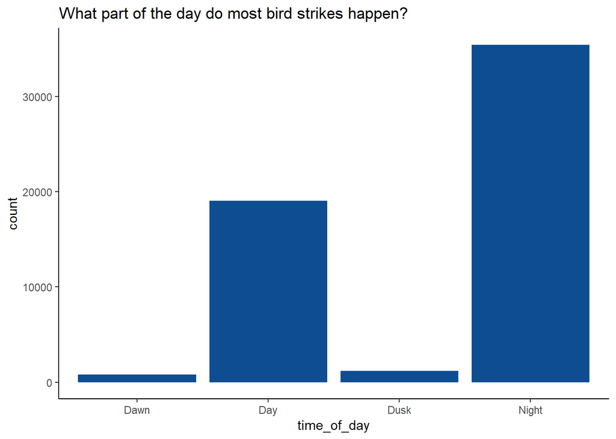

```r
#this is misrepresenting the data because there are more day and night hours in a day
df %>% ggplot(aes(time_of_day))+
  geom_bar(fill="#0f4d92")+
  labs(title="What part of the day do most bird strikes happen?")
```

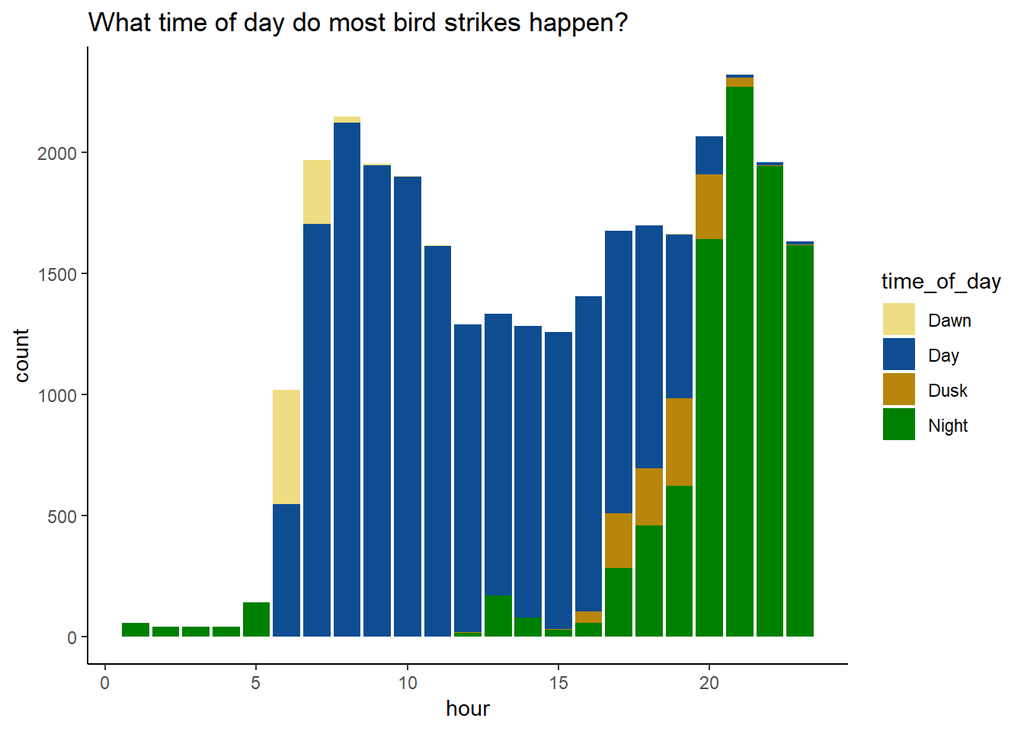

```r
#this is misrepresenting the data because some times are more popular to fly than others
df %>% filter(hour != 0) %>%
  ggplot(aes(hour, fill=time_of_day))+
  geom_bar()+
  scale_fill_manual(values=c("#eedd82","#0f4d92","#b8860b","#008000"))+
  labs(title="What time of day do most bird strikes happen?")
```

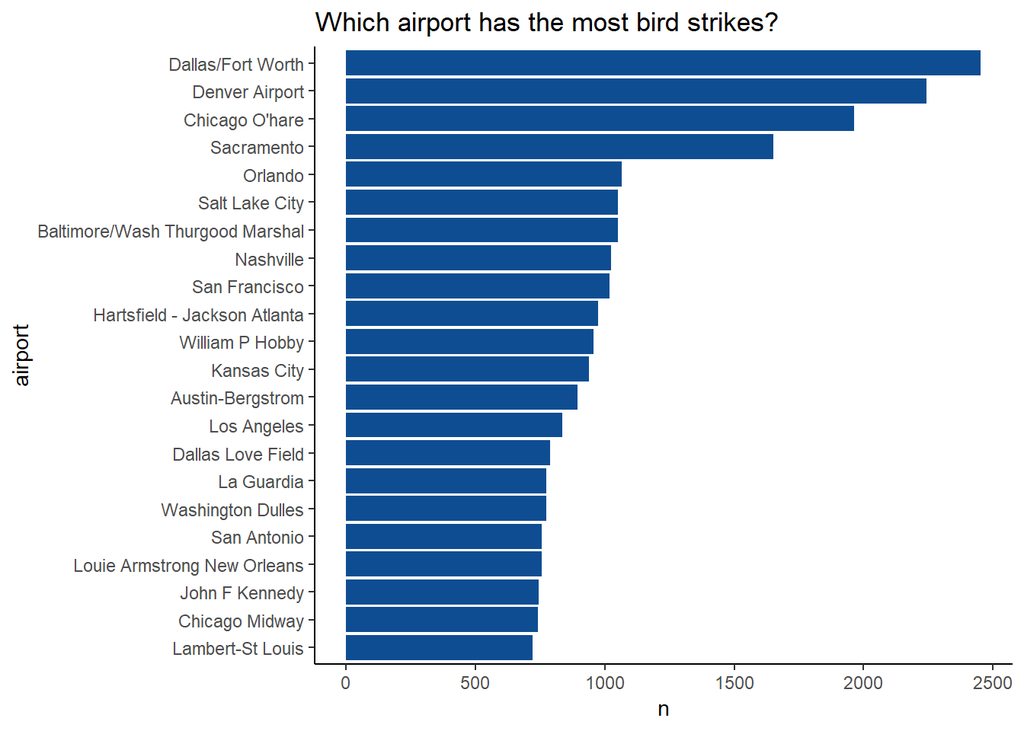

```r
#this could be misrepresenting the data because some airports are busier than others
df %>% filter(airport_id != "ZZZZ") %>% count(airport) %>% filter(n > 700) %>% mutate(airport = fct_reorder(airport,n)) %>%
  ggplot(aes(airport, n))+
  geom_col(fill="#0f4d92")+
  coord_flip()+
  labs(title="Which airport has the most bird strikes?")
```

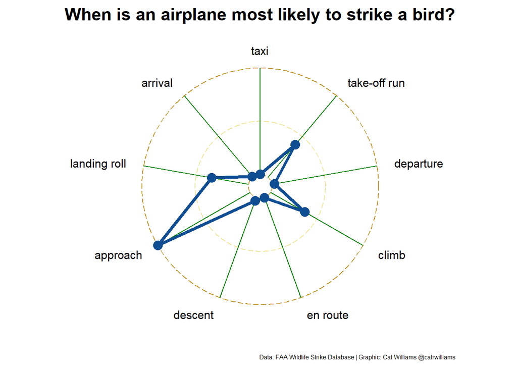

```r
#final visualization
df_flt_phase <- df %>% filter(phase_of_flt != "unknown") %>% count(phase_of_flt)

df_flt_phase <- df_flt_phase %>% mutate_at(vars(n), rescale)

df_flt_phase %>% spread(phase_of_flt,n) %>%
  ggradar(axis.label.size = 4,
          background.circle.colour = "#ffffff",
          values.radar = c("","",""),
          gridline.min.colour = "#b8860b",
          gridline.mid.colour = "#eedd82",
          gridline.max.colour = "#b8860b",
          axis.line.colour = "#008000",
          group.point.size = 4,
          group.colours = "#0f4d92",
          plot.title = "When is an airplane most likely to strike a bird?")+
  labs(caption = "Data: FAA Wildlife Strike Database | Graphic: Cat Williams @catrwilliams")+
  theme(legend.position = "none",
        plot.title = element_text(size=17, hjust=0.5, face="bold"),
        plot.caption = element_text(size=6))
```

```r
ggsave("wildlife-impacts.png")
```